# House_Prices_Coefficients

This is an assignment for my thinkful data science course - "House_Prices_Coefficients" Raj Prasad May 2019

[html version](https://daddyprasad5.github.io/House_Prices_Coefficients.html) - with all the code hidden away for a quick read

[jupyter notebook version](https://github.com/daddyprasad5/thinkful/blob/master/House_Prices_Coefficients.ipynb) - with all the code exposed in an interactive notebook

**NOTE** This exercise adds an addendum to a previous project. The addendum focuses on coefficient interpretation, and the last 2 model runs, at the bottom of the workbook, cover those topics.

## House prices dataset

I'm demonstrating a linear regression modeling on a house prices dataset originally from Kaggle. This dataset consists of 79 variables describing many aspects of residential homes in Ames, Iowa. Using this data, your task will be to predict the prices of the houses. You can find the descriptions of the variables [here](https://www.kaggle.com/c/house-prices-advanced-regression-techniques/data).

The target variable will be the "SalePrice" (the property's sale price in dollars). Since it's a continuous variable, we're dealing with a regression task.

```python
#imports & connection
import numpy as np
import pandas as pd
from sklearn import linear_model
import matplotlib.pyplot as plt
from sqlalchemy import create_engine
import statsmodels.api as sm
import seaborn as sns
from scipy.stats import zscore
from scipy.stats.mstats import winsorize
import scipy.stats as stats

import warnings
warnings.filterwarnings('ignore')
```

```python
#db connection↔
```

```python
#data load
engine = create_engine('postgresql://{}:{}@{}:{}/{}'.format(
    postgres_user, postgres_pw, postgres_host, postgres_port, postgres_db))
houses_df = pd.read_sql_query('select * from houseprices',con=engine)

# no need for an open connection, as we're only doing a single query
engine.dispose()
```

```python
#reset index, head of raw data
houses_df.set_index("id")
houses_df.head()
```

|  | id | mssubclass | mszoning | lotfrontage | lotarea | street | alley | lotshape | landcontour | utilities | ... | poolarea | poolqc | fence | miscfeature | miscval | mosold | yrsold | saletype | salecondition | saleprice |
| --- | --- | --- | --- | --- | --- | --- | --- | --- | --- | --- | --- | --- | --- | --- | --- | --- | --- | --- | --- | --- | --- |
| 0 | 1 | 60 | RL | 65.0 | 8450 | Pave | None | Reg | Lvl | AllPub | ... | 0 | None | None | None | 0 | 2 | 2008 | WD | Normal | 208500 |
| 1 | 2 | 20 | RL | 80.0 | 9600 | Pave | None | Reg | Lvl | AllPub | ... | 0 | None | None | None | 0 | 5 | 2007 | WD | Normal | 181500 |
| 2 | 3 | 60 | RL | 68.0 | 11250 | Pave | None | IR1 | Lvl | AllPub | ... | 0 | None | None | None | 0 | 9 | 2008 | WD | Normal | 223500 |
| 3 | 4 | 70 | RL | 60.0 | 9550 | Pave | None | IR1 | Lvl | AllPub | ... | 0 | None | None | None | 0 | 2 | 2006 | WD | Abnorml | 140000 |
| 4 | 5 | 60 | RL | 84.0 | 14260 | Pave | None | IR1 | Lvl | AllPub | ... | 0 | None | None | None | 0 | 12 | 2008 | WD | Normal | 250000 |

5 rows × 81 columns

```python
houses_df.describe()
```

|  | id | mssubclass | lotfrontage | lotarea | overallqual | overallcond | yearbuilt | yearremodadd | masvnrarea | bsmtfinsf1 | ... | wooddecksf | openporchsf | enclosedporch | threessnporch | screenporch | poolarea | miscval | mosold | yrsold | saleprice |
| --- | --- | --- | --- | --- | --- | --- | --- | --- | --- | --- | --- | --- | --- | --- | --- | --- | --- | --- | --- | --- | --- |
| count | 1460.000000 | 1460.000000 | 1201.000000 | 1460.000000 | 1460.000000 | 1460.000000 | 1460.000000 | 1460.000000 | 1452.000000 | 1460.000000 | ... | 1460.000000 | 1460.000000 | 1460.000000 | 1460.000000 | 1460.000000 | 1460.000000 | 1460.000000 | 1460.000000 | 1460.000000 | 1460.000000 |
| mean | 730.500000 | 56.897260 | 70.049958 | 10516.828082 | 6.099315 | 5.575342 | 1971.267808 | 1984.865753 | 103.685262 | 443.639726 | ... | 94.244521 | 46.660274 | 21.954110 | 3.409589 | 15.060959 | 2.758904 | 43.489041 | 6.321918 | 2007.815753 | 180921.195890 |
| std | 421.610009 | 42.300571 | 24.284752 | 9981.264932 | 1.382997 | 1.112799 | 30.202904 | 20.645407 | 181.066207 | 456.098091 | ... | 125.338794 | 66.256028 | 61.119149 | 29.317331 | 55.757415 | 40.177307 | 496.123024 | 2.703626 | 1.328095 | 79442.502883 |
| min | 1.000000 | 20.000000 | 21.000000 | 1300.000000 | 1.000000 | 1.000000 | 1872.000000 | 1950.000000 | 0.000000 | 0.000000 | ... | 0.000000 | 0.000000 | 0.000000 | 0.000000 | 0.000000 | 0.000000 | 0.000000 | 1.000000 | 2006.000000 | 34900.000000 |
| 25% | 365.750000 | 20.000000 | 59.000000 | 7553.500000 | 5.000000 | 5.000000 | 1954.000000 | 1967.000000 | 0.000000 | 0.000000 | ... | 0.000000 | 0.000000 | 0.000000 | 0.000000 | 0.000000 | 0.000000 | 0.000000 | 5.000000 | 2007.000000 | 129975.000000 |
| 50% | 730.500000 | 50.000000 | 69.000000 | 9478.500000 | 6.000000 | 5.000000 | 1973.000000 | 1994.000000 | 0.000000 | 383.500000 | ... | 0.000000 | 25.000000 | 0.000000 | 0.000000 | 0.000000 | 0.000000 | 0.000000 | 6.000000 | 2008.000000 | 163000.000000 |
| 75% | 1095.250000 | 70.000000 | 80.000000 | 11601.500000 | 7.000000 | 6.000000 | 2000.000000 | 2004.000000 | 166.000000 | 712.250000 | ... | 168.000000 | 68.000000 | 0.000000 | 0.000000 | 0.000000 | 0.000000 | 0.000000 | 8.000000 | 2009.000000 | 214000.000000 |
| max | 1460.000000 | 190.000000 | 313.000000 | 215245.000000 | 10.000000 | 9.000000 | 2010.000000 | 2010.000000 | 1600.000000 | 5644.000000 | ... | 857.000000 | 547.000000 | 552.000000 | 508.000000 | 480.000000 | 738.000000 | 15500.000000 | 12.000000 | 2010.000000 | 755000.000000 |

8 rows × 38 columns

```python
houses_df.describe(include="O")
```

|  | mszoning | street | alley | lotshape | landcontour | utilities | lotconfig | landslope | neighborhood | condition1 | ... | garagetype | garagefinish | garagequal | garagecond | paveddrive | poolqc | fence | miscfeature | saletype | salecondition |
| --- | --- | --- | --- | --- | --- | --- | --- | --- | --- | --- | --- | --- | --- | --- | --- | --- | --- | --- | --- | --- | --- |
| count | 1460 | 1460 | 91 | 1460 | 1460 | 1460 | 1460 | 1460 | 1460 | 1460 | ... | 1379 | 1379 | 1379 | 1379 | 1460 | 7 | 281 | 54 | 1460 | 1460 |
| unique | 5 | 2 | 2 | 4 | 4 | 2 | 5 | 3 | 25 | 9 | ... | 6 | 3 | 5 | 5 | 3 | 3 | 4 | 4 | 9 | 6 |
| top | RL | Pave | Grvl | Reg | Lvl | AllPub | Inside | Gtl | NAmes | Norm | ... | Attchd | Unf | TA | TA | Y | Gd | MnPrv | Shed | WD | Normal |
| freq | 1151 | 1454 | 50 | 925 | 1311 | 1459 | 1052 | 1382 | 225 | 1260 | ... | 870 | 605 | 1311 | 1326 | 1340 | 3 | 157 | 49 | 1267 | 1198 |

4 rows × 43 columns

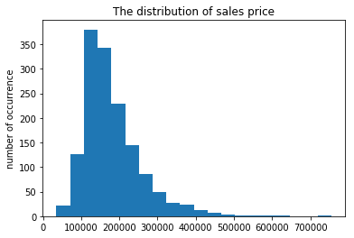

```python
# target variable distribution↔
```

We observe that sales price is not quite normally distributed. Instead, it's highly skewed. **Skewness** is a measure of how asymmetric our data is with respect to the normal distribution. As we see in the graph, the sales price variable is not symmetric but skewed to the right. The majority of the observations have low prices and few of the observations have high prices. This makes the distribution of the charges clustered toward the left.

```python
#look for missing values and drop those columns
#there are plenty of powerful variables without missing values, so I will not spend energy investigating
#variables with missing values.

def remove_null_cols(df):
    n = len(df)
    cols = df.columns
    null_cols = [(len(df[df[col].isnull()]) == 0) for col in df]
    return df.iloc[:, null_cols]

houses_df = remove_null_cols(houses_df)
```

```python
#get all the continuous and categorical columns
#thus far I'm just exploring the categorical columns.  Eventually I would like to explore the continuous.

from itertools import compress

cont_cols = list(compress(houses_df.columns, houses_df.dtypes == int))
cat_cols = list(compress(houses_df.columns, houses_df.dtypes == object))
```

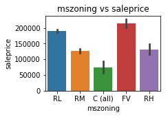

```
t-test between groups RL and RM is significant:  p = 5.31147433276907e-29:
t-test between groups RL and C (all) is significant:  p = 5.781371468431197e-06:
t-test between groups RL and FV is significant:  p = 0.023411437975482768:
t-test between groups RL and RH is significant:  p = 0.0033561549774499266:
t-test between groups RM and C (all) is significant:  p = 0.000997822737851211:
t-test between groups RM and FV is significant:  p = 5.290552561341391e-29:
t-test between groups C (all) and FV is significant:  p = 7.703220225844747e-12:
t-test between groups C (all) and RH is significant:  p = 0.00047440031531897984:
t-test between groups FV and RH is significant:  p = 6.90819126572009e-08:
```

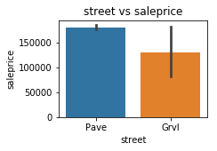

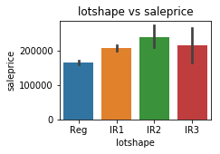

```
t-test between groups Reg and IR1 is significant:  p = 9.171976277508485e-22:
t-test between groups Reg and IR2 is significant:  p = 6.35746592217739e-11:
t-test between groups Reg and IR3 is significant:  p = 0.02107467185053599:
t-test between groups IR1 and IR2 is significant:  p = 0.017484779279881728:
```

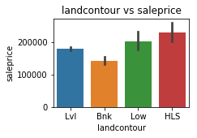

```
t-test between groups Lvl and Bnk is significant:  p = 0.00021137060129819673:
t-test between groups Lvl and HLS is significant:  p = 7.835920892109534e-06:
t-test between groups Bnk and Low is significant:  p = 1.7008132686172627e-05:
t-test between groups Bnk and HLS is significant:  p = 1.9031917524183677e-08:
```

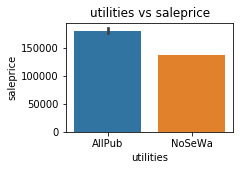

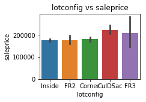

```
t-test between groups Inside and CulDSac is significant:  p = 2.7848227036514676e-08:
t-test between groups FR2 and CulDSac is significant:  p = 0.0027476083240980985:
t-test between groups Corner and CulDSac is significant:  p = 6.344276933784969e-05:
```

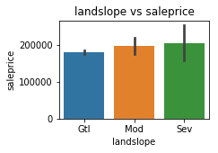

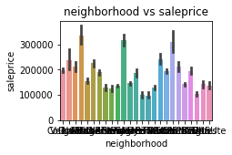

```
t-test between groups CollgCr and Veenker is significant:  p = 0.01471121255220082:
t-test between groups CollgCr and NoRidge is significant:  p = 1.70585467008937e-21:
t-test between groups CollgCr and Mitchel is significant:  p = 3.7808487824887005e-07:
t-test between groups CollgCr and Somerst is significant:  p = 0.00017719270534679517:
t-test between groups CollgCr and OldTown is significant:  p = 1.1938036953251736e-22:
t-test between groups CollgCr and BrkSide is significant:  p = 1.1703954268460629e-18:
t-test between groups CollgCr and Sawyer is significant:  p = 5.077015265496151e-19:
t-test between groups CollgCr and NridgHt is significant:  p = 3.413277523206259e-26:
t-test between groups CollgCr and NAmes is significant:  p = 4.407905553642542e-28:
t-test between groups CollgCr and IDOTRR is significant:  p = 5.349070063364893e-22:
t-test between groups CollgCr and MeadowV is significant:  p = 4.630896998224385e-13:
t-test between groups CollgCr and Edwards is significant:  p = 8.743397807583859e-24:
t-test between groups CollgCr and Timber is significant:  p = 1.2641633386173012e-05:
t-test between groups CollgCr and StoneBr is significant:  p = 5.5640580250250856e-14:
t-test between groups CollgCr and NPkVill is significant:  p = 0.00159286988363606:
t-test between groups CollgCr and BrDale is significant:  p = 1.786419813723039e-11:
t-test between groups CollgCr and SWISU is significant:  p = 5.399076439739743e-07:
t-test between groups Veenker and NoRidge is significant:  p = 0.015410224232563746:
t-test between groups Veenker and Mitchel is significant:  p = 8.216985992999791e-07:
t-test between groups Veenker and NWAmes is significant:  p = 0.0005955430545482236:
t-test between groups Veenker and OldTown is significant:  p = 2.759111891348186e-09:
t-test between groups Veenker and BrkSide is significant:  p = 2.426091950395554e-10:
t-test between groups Veenker and Sawyer is significant:  p = 3.321824423341921e-15:
t-test between groups Veenker and NridgHt is significant:  p = 0.012211619994474135:
t-test between groups Veenker and NAmes is significant:  p = 3.31745953880656e-15:
t-test between groups Veenker and SawyerW is significant:  p = 0.008234890826174006:
t-test between groups Veenker and IDOTRR is significant:  p = 1.0245081879725653e-11:
t-test between groups Veenker and MeadowV is significant:  p = 6.276138410317104e-08:
t-test between groups Veenker and Edwards is significant:  p = 2.2214218973930404e-11:
t-test between groups Veenker and Gilbert is significant:  p = 0.0009586529872052767:
t-test between groups Veenker and NPkVill is significant:  p = 0.0009674035868267627:
t-test between groups Veenker and Blmngtn is significant:  p = 0.03441477557478658:
t-test between groups Veenker and BrDale is significant:  p = 1.2565028479987207e-07:
t-test between groups Veenker and SWISU is significant:  p = 3.281794708920236e-06:
t-test between groups Crawfor and NoRidge is significant:  p = 1.668047313817786e-08:
t-test between groups Crawfor and Mitchel is significant:  p = 3.7502276462528607e-06:
t-test between groups Crawfor and NWAmes is significant:  p = 0.026204159446273082:
t-test between groups Crawfor and OldTown is significant:  p = 2.1252216102938405e-14:
t-test between groups Crawfor and BrkSide is significant:  p = 1.2390575884405268e-12:
t-test between groups Crawfor and Sawyer is significant:  p = 3.043420477890309e-14:
```

[output cut: 180 more lines]

```
t-test between groups StoneBr and Blmngtn is significant:  p = 0.00019327885197259584:
t-test between groups StoneBr and BrDale is significant:  p = 1.0559942671346238e-08:
t-test between groups StoneBr and SWISU is significant:  p = 4.490525175849318e-09:
t-test between groups StoneBr and Blueste is significant:  p = 0.04359054585197499:
t-test between groups ClearCr and NPkVill is significant:  p = 0.00022559161763126653:
t-test between groups ClearCr and BrDale is significant:  p = 1.6866350867189702e-10:
t-test between groups ClearCr and SWISU is significant:  p = 2.603463129135443e-07:
t-test between groups ClearCr and Blueste is significant:  p = 0.04742514333783884:
t-test between groups NPkVill and Blmngtn is significant:  p = 4.338064635067886e-05:
t-test between groups NPkVill and BrDale is significant:  p = 2.798548557430552e-07:
t-test between groups Blmngtn and BrDale is significant:  p = 4.83164335208718e-12:
t-test between groups Blmngtn and SWISU is significant:  p = 5.531666485316795e-06:
t-test between groups Blmngtn and Blueste is significant:  p = 0.019821058385547954:
t-test between groups BrDale and SWISU is significant:  p = 8.325782949580331e-05:
t-test between groups BrDale and Blueste is significant:  p = 0.008492818928429987:
```

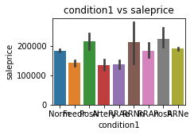

```
t-test between groups Norm and Feedr is significant:  p = 4.3444577659362514e-06:
t-test between groups Norm and Artery is significant:  p = 3.397647338816598e-05:
t-test between groups Feedr and PosN is significant:  p = 2.8218732203779762e-08:
t-test between groups Feedr and RRNn is significant:  p = 0.001410937039704686:
t-test between groups Feedr and RRAn is significant:  p = 0.00024391065053256845:
t-test between groups Feedr and PosA is significant:  p = 1.177174708062123e-06:
t-test between groups PosN and Artery is significant:  p = 3.093055757763581e-05:
t-test between groups PosN and RRAe is significant:  p = 0.0008503447479558294:
t-test between groups Artery and RRNn is significant:  p = 0.020510542921083823:
t-test between groups Artery and RRAn is significant:  p = 0.00312560184203069:
t-test between groups Artery and PosA is significant:  p = 0.0005390325315537501:
t-test between groups RRAe and RRNn is significant:  p = 0.023766739905403376:
t-test between groups RRAe and RRAn is significant:  p = 0.032373745025503234:
t-test between groups RRAe and PosA is significant:  p = 0.00013143243819308488:
t-test between groups RRAe and RRNe is significant:  p = 0.012859093321797327:
```

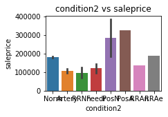

```
t-test between groups Feedr and PosN is significant:  p = 0.0220840758705002:
```

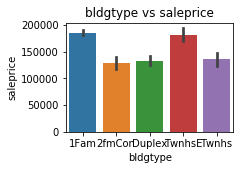

```
t-test between groups 1Fam and 2fmCon is significant:  p = 0.00012309127638279022:
t-test between groups 1Fam and Duplex is significant:  p = 6.046271686674719e-06:
t-test between groups 1Fam and Twnhs is significant:  p = 8.69606941410259e-05:
t-test between groups 2fmCon and TwnhsE is significant:  p = 6.190767497269936e-06:
t-test between groups Duplex and TwnhsE is significant:  p = 1.4731286100745727e-07:
t-test between groups TwnhsE and Twnhs is significant:  p = 8.90624373255204e-06:
```

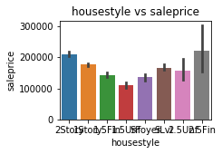

```
t-test between groups 2Story and 1Story is significant:  p = 5.080795678268962e-12:
t-test between groups 2Story and 1.5Fin is significant:  p = 5.254202320262874e-18:
t-test between groups 2Story and 1.5Unf is significant:  p = 2.354869492773719e-05:
t-test between groups 2Story and SFoyer is significant:  p = 3.0899091284796314e-07:
t-test between groups 2Story and SLvl is significant:  p = 9.145925964632968e-05:
t-test between groups 2Story and 2.5Unf is significant:  p = 0.04751995148771409:
t-test between groups 1Story and 1.5Fin is significant:  p = 5.826360271701624e-07:
t-test between groups 1Story and 1.5Unf is significant:  p = 0.0014679975978038765:
t-test between groups 1Story and SFoyer is significant:  p = 0.0013593845492056202:
t-test between groups 1.5Fin and 1.5Unf is significant:  p = 0.02546470487741969:
t-test between groups 1.5Fin and SLvl is significant:  p = 0.001671726205049616:
t-test between groups 1.5Fin and 2.5Fin is significant:  p = 0.000393521621205551:
t-test between groups 1.5Unf and SFoyer is significant:  p = 0.006438660043950879:
t-test between groups 1.5Unf and SLvl is significant:  p = 8.299182635320303e-07:
t-test between groups 1.5Unf and 2.5Unf is significant:  p = 0.01491438143473037:
t-test between groups 1.5Unf and 2.5Fin is significant:  p = 0.0024641263320904767:
t-test between groups SFoyer and SLvl is significant:  p = 3.922036279880214e-05:
t-test between groups SFoyer and 2.5Fin is significant:  p = 0.00029260857960192546:
t-test between groups SLvl and 2.5Fin is significant:  p = 0.007821498731971735:
```

[15 more figures not shown]

```
t-test between groups Normal and Abnorml is significant:  p = 9.765967895233726e-05:
t-test between groups Normal and Partial is significant:  p = 7.738631327816656e-42:
t-test between groups Normal and AdjLand is significant:  p = 0.04177743525925718:
t-test between groups Abnorml and Partial is significant:  p = 2.1037526625948678e-19:
t-test between groups Partial and AdjLand is significant:  p = 0.0015829580514197443:
t-test between groups Partial and Alloca is significant:  p = 0.0009025395714440941:
t-test between groups Partial and Family is significant:  p = 7.015548452188403e-07:
```

```python
#for catgorical variables - get a visual on which variables split house price
#I'm choosing potential categorical variables only on visual inspection,
#but I would like to do this algorithmically in the future.

def cat_to_cont(df, cat, cont, threshold):
    """creates a barplot and conducts t-test
    for a categorical to continuous relationship"""

    #group by
    unique_vals = df[cat].unique()
    grouped_df = df[[cat, cont]].groupby(cat).mean()

    #barplot
    plt.figure(figsize=(3, 2))
    sns.barplot(df[cat], df[cont])
    plt.title("{} vs {}".format(cat, cont))
    plt.show()

    #t-test
    for i in range(0, len(unique_vals)):
        for j in range(i+1, len(unique_vals)):
            t, p = stats.ttest_ind(
                df[df[cat]==unique_vals[i]][cont],
                df[df[cat]==unique_vals[j]][cont])
            if p < threshold:
                print("t-test between groups {0} and {1} is significant:  p = {2}:"
                      .format(unique_vals[i], unique_vals[j], p))


for cat in cat_cols:
    cat_to_cont(houses_df, cat, "saleprice", .05)
```

```python
#transform the promising categorical variables to one-hot columns and create a features dataframe
neighborhood_df = pd.get_dummies(houses_df.neighborhood, prefix='neighborhood', drop_first=True)
mszoning_df = pd.get_dummies(houses_df.mszoning, prefix='mszoning', drop_first=True)
exterqual_df = pd.get_dummies(houses_df.exterqual, prefix='exterqual', drop_first=True)
kitchenqual_df = pd.get_dummies(houses_df.kitchenqual, prefix='kitchenqual', drop_first=True)
heatingqc_df = pd.get_dummies(houses_df.heatingqc, prefix='heatingqc', drop_first=True)
salecondition_df = pd.get_dummies(houses_df.salecondition, prefix='salecondition', drop_first=True)

features = pd.concat([neighborhood_df, mszoning_df, exterqual_df,
                      kitchenqual_df, heatingqc_df, salecondition_df],
                    axis=1)
```

## An initial model for home prices

Build a simple linear regression model using all of our promising one-hot features (including some highly-correlated features) and estimate it using OLS.

```python
# Y is the target variable
Y = houses_df['saleprice']
# X is the feature set which includes
# is_male and is_smoker variables
X = features

# We need to manually add a constant
# in statsmodels' sm
X = sm.add_constant(X)

lrm = sm.OLS(Y, X)

results = sm.OLS(Y, X).fit()

results.summary()
```

OLS Regression Results

| Dep. Variable: | saleprice | R-squared: | 0.696 |
| --- | --- | --- | --- |
| Model: | OLS | Adj. R-squared: | 0.687 |
| Method: | Least Squares | F-statistic: | 75.54 |
| Date: | Wed, 29 May 2019 | Prob (F-statistic): | 0.00 |
| Time: | 05:08:26 | Log-Likelihood: | -17674. |
| No. Observations: | 1460 | AIC: | 3.544e+04 |
| Df Residuals: | 1416 | BIC: | 3.567e+04 |
| Df Model: | 43 |  |  |
| Covariance Type: | nonrobust |  |  |

|  | coef | std err | t | P>\|t\| | [0.025 | 0.975] |
| --- | --- | --- | --- | --- | --- | --- |
| const | 2.668e+05 | 2.19e+04 | 12.167 | 0.000 | 2.24e+05 | 3.1e+05 |
| neighborhood_Blueste | 1.408e+04 | 3.4e+04 | 0.414 | 0.679 | -5.27e+04 | 8.09e+04 |
| neighborhood_BrDale | -1.725e+04 | 1.72e+04 | -1.005 | 0.315 | -5.09e+04 | 1.64e+04 |
| neighborhood_BrkSide | -6229.7243 | 1.33e+04 | -0.470 | 0.638 | -3.22e+04 | 1.98e+04 |
| neighborhood_ClearCr | 5.614e+04 | 1.4e+04 | 4.008 | 0.000 | 2.87e+04 | 8.36e+04 |
| neighborhood_CollgCr | 1.873e+04 | 1.14e+04 | 1.638 | 0.102 | -3708.322 | 4.12e+04 |
| neighborhood_Crawfor | 5.428e+04 | 1.28e+04 | 4.232 | 0.000 | 2.91e+04 | 7.94e+04 |
| neighborhood_Edwards | -1.73e+04 | 1.22e+04 | -1.414 | 0.158 | -4.13e+04 | 6708.812 |
| neighborhood_Gilbert | 2.435e+04 | 1.21e+04 | 2.018 | 0.044 | 675.178 | 4.8e+04 |
| neighborhood_IDOTRR | -1.476e+04 | 1.55e+04 | -0.955 | 0.340 | -4.51e+04 | 1.56e+04 |
| neighborhood_MeadowV | -3.091e+04 | 1.69e+04 | -1.832 | 0.067 | -6.4e+04 | 2182.181 |
| neighborhood_Mitchel | 1.327e+04 | 1.3e+04 | 1.018 | 0.309 | -1.23e+04 | 3.88e+04 |
| neighborhood_NAmes | 5308.2068 | 1.18e+04 | 0.449 | 0.654 | -1.79e+04 | 2.85e+04 |
| neighborhood_NPkVill | 9846.1700 | 1.89e+04 | 0.522 | 0.602 | -2.71e+04 | 4.68e+04 |
| neighborhood_NWAmes | 4.266e+04 | 1.25e+04 | 3.409 | 0.001 | 1.81e+04 | 6.72e+04 |
| neighborhood_NoRidge | 1.429e+05 | 1.29e+04 | 11.058 | 0.000 | 1.18e+05 | 1.68e+05 |
| neighborhood_NridgHt | 6.743e+04 | 1.23e+04 | 5.499 | 0.000 | 4.34e+04 | 9.15e+04 |
| neighborhood_OldTown | -6150.7275 | 1.32e+04 | -0.467 | 0.640 | -3.2e+04 | 1.97e+04 |
| neighborhood_SWISU | 5359.8208 | 1.46e+04 | 0.366 | 0.714 | -2.33e+04 | 3.41e+04 |
| neighborhood_Sawyer | -1395.2406 | 1.26e+04 | -0.111 | 0.912 | -2.61e+04 | 2.33e+04 |
| neighborhood_SawyerW | 2.145e+04 | 1.25e+04 | 1.718 | 0.086 | -3036.113 | 4.59e+04 |
| neighborhood_Somerst | 4.17e+04 | 1.46e+04 | 2.860 | 0.004 | 1.31e+04 | 7.03e+04 |
| neighborhood_StoneBr | 8.896e+04 | 1.41e+04 | 6.308 | 0.000 | 6.13e+04 | 1.17e+05 |
| neighborhood_Timber | 5.875e+04 | 1.31e+04 | 4.493 | 0.000 | 3.31e+04 | 8.44e+04 |
| neighborhood_Veenker | 5.937e+04 | 1.73e+04 | 3.423 | 0.001 | 2.53e+04 | 9.34e+04 |
| mszoning_FV | 1.029e+04 | 2.07e+04 | 0.498 | 0.618 | -3.02e+04 | 5.08e+04 |
| mszoning_RH | 1.872e+04 | 2.08e+04 | 0.902 | 0.367 | -2.2e+04 | 5.94e+04 |
| mszoning_RL | 3.212e+04 | 1.74e+04 | 1.849 | 0.065 | -1957.146 | 6.62e+04 |
| mszoning_RM | 2.216e+04 | 1.64e+04 | 1.349 | 0.177 | -1.01e+04 | 5.44e+04 |
| exterqual_Fa | -1.039e+05 | 1.59e+04 | -6.540 | 0.000 | -1.35e+05 | -7.28e+04 |
| exterqual_Gd | -6.71e+04 | 7981.249 | -8.408 | 0.000 | -8.28e+04 | -5.14e+04 |
| exterqual_TA | -8.917e+04 | 8724.657 | -10.220 | 0.000 | -1.06e+05 | -7.21e+04 |
| kitchenqual_Fa | -9.906e+04 | 1.02e+04 | -9.670 | 0.000 | -1.19e+05 | -7.9e+04 |
| kitchenqual_Gd | -6.145e+04 | 5980.485 | -10.276 | 0.000 | -7.32e+04 | -4.97e+04 |
| kitchenqual_TA | -8.289e+04 | 6599.906 | -12.559 | 0.000 | -9.58e+04 | -6.99e+04 |
| heatingqc_Fa | -1.974e+04 | 7049.830 | -2.801 | 0.005 | -3.36e+04 | -5914.305 |
| heatingqc_Gd | -1.101e+04 | 3664.916 | -3.005 | 0.003 | -1.82e+04 | -3824.986 |
| heatingqc_Po | -3.134e+04 | 4.53e+04 | -0.692 | 0.489 | -1.2e+05 | 5.75e+04 |
| heatingqc_TA | -9689.3092 | 3452.201 | -2.807 | 0.005 | -1.65e+04 | -2917.330 |
| salecondition_AdjLand | 1.076e+04 | 2.32e+04 | 0.463 | 0.643 | -3.48e+04 | 5.63e+04 |
| salecondition_Alloca | 3.823e+04 | 1.39e+04 | 2.741 | 0.006 | 1.09e+04 | 6.56e+04 |
| salecondition_Family | 9429.2725 | 1.1e+04 | 0.856 | 0.392 | -1.22e+04 | 3.1e+04 |
| salecondition_Normal | 1.615e+04 | 4739.390 | 3.408 | 0.001 | 6852.795 | 2.54e+04 |
| salecondition_Partial | 3.409e+04 | 6628.000 | 5.143 | 0.000 | 2.11e+04 | 4.71e+04 |

| Omnibus: | 552.636 | Durbin-Watson: | 1.979 |
| --- | --- | --- | --- |
| Prob(Omnibus): | 0.000 | Jarque-Bera (JB): | 5043.635 |
| Skew: | 1.503 | Prob(JB): | 0.00 |
| Kurtosis: | 11.595 | Cond. No. | 93.1 |

Warnings:  
[1] Standard Errors assume that the covariance matrix of the errors is correctly specified.

```python
#1. linearity of models in their coefficients - the model chosen de facto satisfies this condition
```

```python
#2. the error term should be zero on average - and it is very close.  No concerns here. ↔
```

```
Mean of the errors in the medical costs model is: 8.726364945712155e-10
```

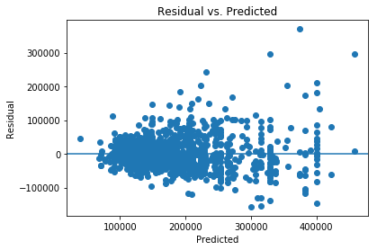

```
Bartlett test statistic value is 244.419 and p value is 4.28e-55
Levene test statistic value is 181.276 and p value is 3.93e-40
```

```python
#3. homoscedasticity: the errors are consistently distributed  ↔
```

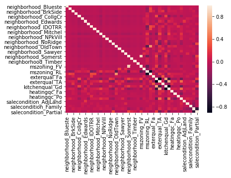

```python
#4. low multicollinearity - THERE ARE A FEW HIGHLY CORRELATED FEATURE PAIRS. ↔
```

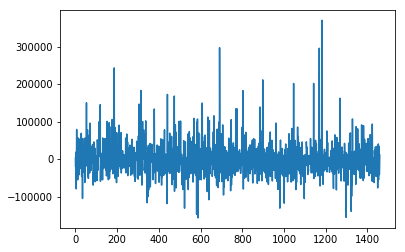

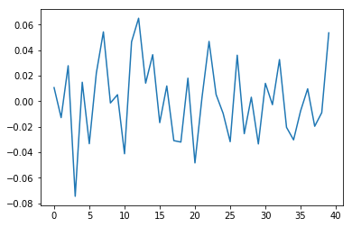

```python
#5. error terms are not correlated with each other. ↔
```

```python
#6. features shouldn't be correlated with the errors - and they aren't↔
```

|  | feature | correlation with error >0.1 |
| --- | --- | --- |

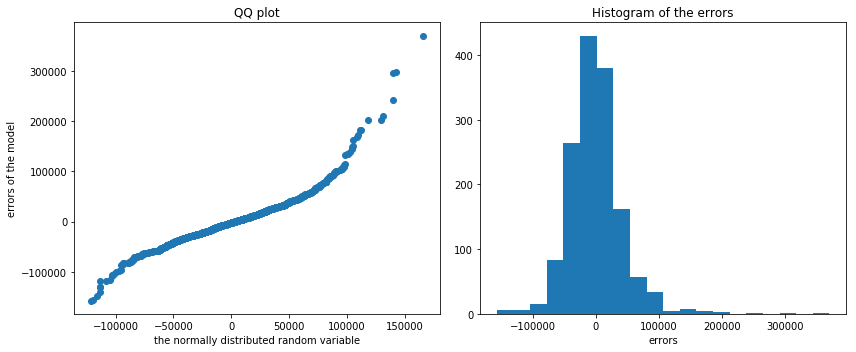

```
Jarque-Bera test statistics is 5043.63518125381 and p value is 0.0
Normality test statistics is 552.6363431250936 and p value is 9.920711968432696e-121
```

```python
#7. ERRORS ARE NOT NORMALLY DISTRIBUTED. ↔
```

We've found 2 concerns:

- There are a few highly correlated feature pairs.
- The errors are not normally distribured

To mitigate both concerns, let's create a second feature set that (a) removes the least powerful feature in each highly correlated pair and (b) adds some more features.

```python
#find some powerful continuous variables↔
```

```
<class 'pandas.core.frame.DataFrame'>
Index(['neighborhood_Blueste', 'neighborhood_BrDale', 'neighborhood_BrkSide',
       'neighborhood_ClearCr', 'neighborhood_CollgCr', 'neighborhood_Crawfor',
       'neighborhood_Edwards', 'neighborhood_Gilbert', 'neighborhood_IDOTRR',
       'neighborhood_MeadowV', 'neighborhood_Mitchel', 'neighborhood_NAmes',
       'neighborhood_NPkVill', 'neighborhood_NWAmes', 'neighborhood_NoRidge',
       'neighborhood_NridgHt', 'neighborhood_OldTown', 'neighborhood_SWISU',
       'neighborhood_Sawyer', 'neighborhood_SawyerW', 'neighborhood_Somerst',
       'neighborhood_StoneBr', 'neighborhood_Timber', 'neighborhood_Veenker',
       'mszoning_FV', 'mszoning_RH', 'mszoning_RL', 'mszoning_RM',
       'exterqual_Fa', 'exterqual_Gd', 'exterqual_TA', 'kitchenqual_Fa',
       'kitchenqual_Gd', 'kitchenqual_TA', 'heatingqc_Fa', 'heatingqc_Gd',
       'heatingqc_Po', 'heatingqc_TA', 'salecondition_AdjLand',
       'salecondition_Alloca', 'salecondition_Family', 'salecondition_Normal',
       'salecondition_Partial', 'overallqual', 'grlivarea', 'garagecars',
       'garagearea', 'totalbsmtsf'],
      dtype='object')
```

```python
#find highly correlated feature pairs and remove the one with lowest correlation with sales price↔
```

```
dropped features: {'exterqual_Gd', 'garagecars', 'totalbsmtsf', 'kitchenqual_TA', 'garagearea', 'salecondition_Normal', 'kitchenqual_Gd', 'grlivarea', 'exterqual_TA', 'mszoning_RL', 'mszoning_FV', 'neighborhood_OldTown'}
reduced features list: Index(['neighborhood_Blueste', 'neighborhood_BrDale', 'neighborhood_BrkSide',
       'neighborhood_ClearCr', 'neighborhood_CollgCr', 'neighborhood_Crawfor',
       'neighborhood_Edwards', 'neighborhood_Gilbert', 'neighborhood_IDOTRR',
       'neighborhood_MeadowV', 'neighborhood_Mitchel', 'neighborhood_NAmes',
       'neighborhood_NPkVill', 'neighborhood_NWAmes', 'neighborhood_NoRidge',
       'neighborhood_NridgHt', 'neighborhood_SWISU', 'neighborhood_Sawyer',
       'neighborhood_SawyerW', 'neighborhood_Somerst', 'neighborhood_StoneBr',
       'neighborhood_Timber', 'neighborhood_Veenker', 'mszoning_RH',
       'mszoning_RM', 'exterqual_Fa', 'kitchenqual_Fa', 'heatingqc_Fa',
       'heatingqc_Gd', 'heatingqc_Po', 'heatingqc_TA', 'salecondition_AdjLand',
       'salecondition_Alloca', 'salecondition_Family', 'salecondition_Partial',
       'overallqual'],
      dtype='object')
```

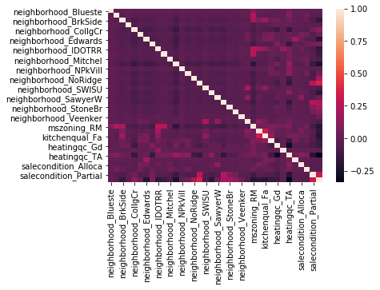

```python
#the new correlation heatmap looks pretty good↔
```

## A model with the reduced features set

Let's build a new model with the new feature set.

```python
# Y is the target variable
Y = houses_df['saleprice']
# X is the feature set which includes
# is_male and is_smoker variables
X = features2

# We need to manually add a constant
# in statsmodels' sm
X = sm.add_constant(X)

results = sm.OLS(Y, X).fit()

results.summary()
```

OLS Regression Results

| Dep. Variable: | saleprice | R-squared: | 0.728 |
| --- | --- | --- | --- |
| Model: | OLS | Adj. R-squared: | 0.722 |
| Method: | Least Squares | F-statistic: | 106.0 |
| Date: | Wed, 29 May 2019 | Prob (F-statistic): | 0.00 |
| Time: | 05:08:30 | Log-Likelihood: | -17592. |
| No. Observations: | 1460 | AIC: | 3.526e+04 |
| Df Residuals: | 1423 | BIC: | 3.545e+04 |
| Df Model: | 36 |  |  |
| Covariance Type: | nonrobust |  |  |

|  | coef | std err | t | P>\|t\| | [0.025 | 0.975] |
| --- | --- | --- | --- | --- | --- | --- |
| const | -2.904e+04 | 8776.422 | -3.309 | 0.001 | -4.63e+04 | -1.18e+04 |
| neighborhood_Blueste | -2673.4780 | 3e+04 | -0.089 | 0.929 | -6.15e+04 | 5.61e+04 |
| neighborhood_BrDale | -2.568e+04 | 1.13e+04 | -2.273 | 0.023 | -4.78e+04 | -3521.905 |
| neighborhood_BrkSide | 5882.9789 | 6804.575 | 0.865 | 0.387 | -7465.096 | 1.92e+04 |
| neighborhood_ClearCr | 5.622e+04 | 9488.454 | 5.925 | 0.000 | 3.76e+04 | 7.48e+04 |
| neighborhood_CollgCr | 1.177e+04 | 6228.030 | 1.890 | 0.059 | -446.518 | 2.4e+04 |
| neighborhood_Crawfor | 4.404e+04 | 7809.929 | 5.639 | 0.000 | 2.87e+04 | 5.94e+04 |
| neighborhood_Edwards | 165.1731 | 6548.128 | 0.025 | 0.980 | -1.27e+04 | 1.3e+04 |
| neighborhood_Gilbert | 9461.2735 | 7131.162 | 1.327 | 0.185 | -4527.445 | 2.34e+04 |
| neighborhood_IDOTRR | -6354.6662 | 8097.178 | -0.785 | 0.433 | -2.22e+04 | 9529.021 |
| neighborhood_MeadowV | 6222.1600 | 1.1e+04 | 0.565 | 0.572 | -1.54e+04 | 2.78e+04 |
| neighborhood_Mitchel | 1.091e+04 | 7748.286 | 1.408 | 0.159 | -4286.197 | 2.61e+04 |
| neighborhood_NAmes | 9789.2364 | 5942.225 | 1.647 | 0.100 | -1867.224 | 2.14e+04 |
| neighborhood_NPkVill | -1.167e+04 | 1.51e+04 | -0.775 | 0.439 | -4.12e+04 | 1.79e+04 |
| neighborhood_NWAmes | 2.256e+04 | 7286.256 | 3.097 | 0.002 | 8269.438 | 3.69e+04 |
| neighborhood_NoRidge | 1.096e+05 | 8840.065 | 12.399 | 0.000 | 9.23e+04 | 1.27e+05 |
| neighborhood_NridgHt | 6.741e+04 | 7772.216 | 8.673 | 0.000 | 5.22e+04 | 8.27e+04 |
| neighborhood_SWISU | 4649.1226 | 1.02e+04 | 0.457 | 0.648 | -1.53e+04 | 2.46e+04 |
| neighborhood_Sawyer | 1.1e+04 | 7118.944 | 1.545 | 0.123 | -2964.461 | 2.5e+04 |
| neighborhood_SawyerW | 1.545e+04 | 7703.915 | 2.005 | 0.045 | 334.964 | 3.06e+04 |
| neighborhood_Somerst | 7396.3066 | 7298.955 | 1.013 | 0.311 | -6921.560 | 2.17e+04 |
| neighborhood_StoneBr | 6.985e+04 | 1.03e+04 | 6.771 | 0.000 | 4.96e+04 | 9.01e+04 |
| neighborhood_Timber | 3.847e+04 | 8752.431 | 4.395 | 0.000 | 2.13e+04 | 5.56e+04 |
| neighborhood_Veenker | 5.535e+04 | 1.38e+04 | 4.025 | 0.000 | 2.84e+04 | 8.23e+04 |
| mszoning_RH | -1.608e+04 | 1.12e+04 | -1.442 | 0.150 | -3.8e+04 | 5801.852 |
| mszoning_RM | -1.463e+04 | 4932.864 | -2.966 | 0.003 | -2.43e+04 | -4956.650 |
| exterqual_Fa | 1.226e+04 | 1.24e+04 | 0.989 | 0.323 | -1.21e+04 | 3.66e+04 |
| kitchenqual_Fa | -4369.4108 | 7584.468 | -0.576 | 0.565 | -1.92e+04 | 1.05e+04 |
| heatingqc_Fa | -1.348e+04 | 6596.538 | -2.044 | 0.041 | -2.64e+04 | -541.009 |
| heatingqc_Gd | -9352.6396 | 3391.203 | -2.758 | 0.006 | -1.6e+04 | -2700.346 |
| heatingqc_Po | -2.408e+04 | 4.26e+04 | -0.565 | 0.572 | -1.08e+05 | 5.95e+04 |
| heatingqc_TA | -9480.1871 | 3118.049 | -3.040 | 0.002 | -1.56e+04 | -3363.721 |
| salecondition_AdjLand | -1.653e+04 | 2.15e+04 | -0.768 | 0.442 | -5.87e+04 | 2.57e+04 |
| salecondition_Alloca | 1.854e+04 | 1.25e+04 | 1.484 | 0.138 | -5961.486 | 4.31e+04 |
| salecondition_Family | -8622.1479 | 9550.868 | -0.903 | 0.367 | -2.74e+04 | 1.01e+04 |
| salecondition_Partial | 2.935e+04 | 4450.828 | 6.595 | 0.000 | 2.06e+04 | 3.81e+04 |
| overallqual | 3.222e+04 | 1180.207 | 27.301 | 0.000 | 2.99e+04 | 3.45e+04 |

| Omnibus: | 621.495 | Durbin-Watson: | 1.916 |
| --- | --- | --- | --- |
| Prob(Omnibus): | 0.000 | Jarque-Bera (JB): | 7427.754 |
| Skew: | 1.648 | Prob(JB): | 0.00 |
| Kurtosis: | 13.547 | Cond. No. | 246. |

Warnings:  
[1] Standard Errors assume that the covariance matrix of the errors is correctly specified.

This both reduced the multi-colinearity problem and improved the predictive power of the model (from R=.70 to R=.73).

Let's see if it improved the normality of the errors.

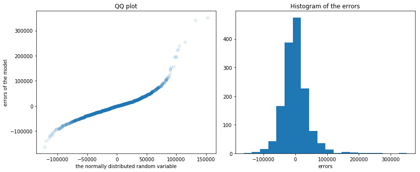

```
Jarque-Bera test statistics is 7427.754287093701 and p value is 0.0
Normality test statistics is 621.4948041627138 and p value is 1.1069245263308023e-135
```

```python
#7. ERRORS ARE NOT NORMALLY DISTRIBUTED. ↔
```

Still not normal per the Jarque-Bera and Normality tests.

What do the high error rows look like?

```python
#get the index values where the errors are > 150000↔
```

|  | id | mssubclass | mszoning | lotarea | street | lotshape | landcontour | utilities | lotconfig | landslope | ... | enclosedporch | threessnporch | screenporch | poolarea | miscval | mosold | yrsold | saletype | salecondition | saleprice |
| --- | --- | --- | --- | --- | --- | --- | --- | --- | --- | --- | --- | --- | --- | --- | --- | --- | --- | --- | --- | --- | --- |
| 186 | 186 | 75 | RM | 22950 | Pave | IR2 | Lvl | AllPub | Inside | Gtl | ... | 0 | 0 | 410 | 0 | 0 | 6 | 2006 | WD | Normal | 475000 |
| 441 | 441 | 20 | RL | 15431 | Pave | Reg | Lvl | AllPub | Inside | Gtl | ... | 0 | 0 | 170 | 0 | 0 | 4 | 2009 | WD | Normal | 555000 |
| 664 | 665 | 20 | RL | 20896 | Pave | IR2 | Lvl | AllPub | CulDSac | Gtl | ... | 0 | 0 | 0 | 0 | 0 | 1 | 2006 | New | Partial | 423000 |
| 691 | 692 | 60 | RL | 21535 | Pave | IR1 | Lvl | AllPub | Corner | Gtl | ... | 0 | 0 | 0 | 0 | 0 | 1 | 2007 | WD | Normal | 755000 |
| 769 | 770 | 60 | RL | 53504 | Pave | IR2 | HLS | AllPub | CulDSac | Mod | ... | 0 | 0 | 210 | 0 | 0 | 6 | 2010 | WD | Normal | 538000 |
| 803 | 804 | 60 | RL | 13891 | Pave | Reg | Lvl | AllPub | Inside | Gtl | ... | 0 | 0 | 192 | 0 | 0 | 1 | 2009 | New | Partial | 582933 |
| 898 | 899 | 20 | RL | 12919 | Pave | IR1 | Lvl | AllPub | Inside | Gtl | ... | 0 | 0 | 0 | 0 | 0 | 3 | 2010 | New | Partial | 611657 |
| 1046 | 1047 | 60 | RL | 16056 | Pave | IR1 | Lvl | AllPub | Inside | Gtl | ... | 0 | 0 | 0 | 0 | 0 | 7 | 2006 | New | Partial | 556581 |
| 1142 | 1143 | 60 | RL | 9965 | Pave | Reg | Lvl | AllPub | Inside | Gtl | ... | 0 | 0 | 0 | 0 | 0 | 4 | 2007 | New | Partial | 424870 |
| 1169 | 1170 | 60 | RL | 35760 | Pave | IR1 | Lvl | AllPub | CulDSac | Gtl | ... | 0 | 0 | 0 | 0 | 0 | 7 | 2006 | WD | Normal | 625000 |
| 1182 | 1183 | 60 | RL | 15623 | Pave | IR1 | Lvl | AllPub | Corner | Gtl | ... | 0 | 0 | 0 | 555 | 0 | 7 | 2007 | WD | Abnorml | 745000 |

11 rows × 62 columns

```python
houses_df[houses_df.saleprice > 530000]
```

|  | id | mssubclass | mszoning | lotarea | street | lotshape | landcontour | utilities | lotconfig | landslope | ... | enclosedporch | threessnporch | screenporch | poolarea | miscval | mosold | yrsold | saletype | salecondition | saleprice |
| --- | --- | --- | --- | --- | --- | --- | --- | --- | --- | --- | --- | --- | --- | --- | --- | --- | --- | --- | --- | --- | --- |
| 441 | 441 | 20 | RL | 15431 | Pave | Reg | Lvl | AllPub | Inside | Gtl | ... | 0 | 0 | 170 | 0 | 0 | 4 | 2009 | WD | Normal | 555000 |
| 691 | 692 | 60 | RL | 21535 | Pave | IR1 | Lvl | AllPub | Corner | Gtl | ... | 0 | 0 | 0 | 0 | 0 | 1 | 2007 | WD | Normal | 755000 |
| 769 | 770 | 60 | RL | 53504 | Pave | IR2 | HLS | AllPub | CulDSac | Mod | ... | 0 | 0 | 210 | 0 | 0 | 6 | 2010 | WD | Normal | 538000 |
| 803 | 804 | 60 | RL | 13891 | Pave | Reg | Lvl | AllPub | Inside | Gtl | ... | 0 | 0 | 192 | 0 | 0 | 1 | 2009 | New | Partial | 582933 |
| 898 | 899 | 20 | RL | 12919 | Pave | IR1 | Lvl | AllPub | Inside | Gtl | ... | 0 | 0 | 0 | 0 | 0 | 3 | 2010 | New | Partial | 611657 |
| 1046 | 1047 | 60 | RL | 16056 | Pave | IR1 | Lvl | AllPub | Inside | Gtl | ... | 0 | 0 | 0 | 0 | 0 | 7 | 2006 | New | Partial | 556581 |
| 1169 | 1170 | 60 | RL | 35760 | Pave | IR1 | Lvl | AllPub | CulDSac | Gtl | ... | 0 | 0 | 0 | 0 | 0 | 7 | 2006 | WD | Normal | 625000 |
| 1182 | 1183 | 60 | RL | 15623 | Pave | IR1 | Lvl | AllPub | Corner | Gtl | ... | 0 | 0 | 0 | 555 | 0 | 7 | 2007 | WD | Abnorml | 745000 |

8 rows × 62 columns

It turns out they are very similar. Most notably the 11 outliers include the 8 most expensive houses in the dataset. If we removed those from the dataset and re-built the model, what would the normality test look like?

```python
purged_index = list(houses_df.loc[houses_df.saleprice < 530000].index.values)

# Y is the target variable
Y = houses_df.loc[purged_index, 'saleprice']
# X is the feature set which includes
# is_male and is_smoker variables
X = features2.loc[purged_index, :]

# We need to manually add a constant
# in statsmodels' sm
X = sm.add_constant(X)

results = sm.OLS(Y, X).fit()

results.summary()
```

OLS Regression Results

| Dep. Variable: | saleprice | R-squared: | 0.748 |
| --- | --- | --- | --- |
| Model: | OLS | Adj. R-squared: | 0.741 |
| Method: | Least Squares | F-statistic: | 116.4 |
| Date: | Wed, 29 May 2019 | Prob (F-statistic): | 0.00 |
| Time: | 05:08:30 | Log-Likelihood: | -17307. |
| No. Observations: | 1452 | AIC: | 3.469e+04 |
| Df Residuals: | 1415 | BIC: | 3.488e+04 |
| Df Model: | 36 |  |  |
| Covariance Type: | nonrobust |  |  |

|  | coef | std err | t | P>\|t\| | [0.025 | 0.975] |
| --- | --- | --- | --- | --- | --- | --- |
| const | -1.658e+04 | 7740.358 | -2.141 | 0.032 | -3.18e+04 | -1391.266 |
| neighborhood_Blueste | -1640.8983 | 2.63e+04 | -0.062 | 0.950 | -5.33e+04 | 5e+04 |
| neighborhood_BrDale | -2.549e+04 | 9919.961 | -2.570 | 0.010 | -4.5e+04 | -6033.075 |
| neighborhood_BrkSide | 4915.7475 | 5975.964 | 0.823 | 0.411 | -6806.953 | 1.66e+04 |
| neighborhood_ClearCr | 5.693e+04 | 8332.844 | 6.832 | 0.000 | 4.06e+04 | 7.33e+04 |
| neighborhood_CollgCr | 1.41e+04 | 5470.726 | 2.577 | 0.010 | 3365.452 | 2.48e+04 |
| neighborhood_Crawfor | 4.572e+04 | 6859.428 | 6.666 | 0.000 | 3.23e+04 | 5.92e+04 |
| neighborhood_Edwards | -736.7479 | 5750.753 | -0.128 | 0.898 | -1.2e+04 | 1.05e+04 |
| neighborhood_Gilbert | 1.158e+04 | 6263.526 | 1.849 | 0.065 | -705.582 | 2.39e+04 |
| neighborhood_IDOTRR | -7732.3740 | 7111.261 | -1.087 | 0.277 | -2.17e+04 | 6217.374 |
| neighborhood_MeadowV | 3667.5488 | 9672.886 | 0.379 | 0.705 | -1.53e+04 | 2.26e+04 |
| neighborhood_Mitchel | 1.099e+04 | 6804.551 | 1.615 | 0.107 | -2362.019 | 2.43e+04 |
| neighborhood_NAmes | 9411.1242 | 5218.562 | 1.803 | 0.072 | -825.827 | 1.96e+04 |
| neighborhood_NPkVill | -1.026e+04 | 1.32e+04 | -0.776 | 0.438 | -3.62e+04 | 1.57e+04 |
| neighborhood_NWAmes | 2.434e+04 | 6399.878 | 3.803 | 0.000 | 1.18e+04 | 3.69e+04 |
| neighborhood_NoRidge | 8.995e+04 | 7887.213 | 11.405 | 0.000 | 7.45e+04 | 1.05e+05 |
| neighborhood_NridgHt | 6.462e+04 | 6863.990 | 9.414 | 0.000 | 5.12e+04 | 7.81e+04 |
| neighborhood_SWISU | 4851.9212 | 8940.825 | 0.543 | 0.587 | -1.27e+04 | 2.24e+04 |
| neighborhood_Sawyer | 9892.3600 | 6252.126 | 1.582 | 0.114 | -2372.073 | 2.22e+04 |
| neighborhood_SawyerW | 1.71e+04 | 6766.334 | 2.527 | 0.012 | 3823.104 | 3.04e+04 |
| neighborhood_Somerst | 1.174e+04 | 6414.391 | 1.831 | 0.067 | -838.388 | 2.43e+04 |
| neighborhood_StoneBr | 5.685e+04 | 9310.003 | 6.106 | 0.000 | 3.86e+04 | 7.51e+04 |
| neighborhood_Timber | 4.212e+04 | 7688.757 | 5.478 | 0.000 | 2.7e+04 | 5.72e+04 |
| neighborhood_Veenker | 5.781e+04 | 1.21e+04 | 4.787 | 0.000 | 3.41e+04 | 8.15e+04 |
| mszoning_RH | -1.696e+04 | 9798.244 | -1.731 | 0.084 | -3.62e+04 | 2263.651 |
| mszoning_RM | -1.432e+04 | 4332.111 | -3.306 | 0.001 | -2.28e+04 | -5822.078 |
| exterqual_Fa | 9920.8190 | 1.09e+04 | 0.911 | 0.362 | -1.14e+04 | 3.13e+04 |
| kitchenqual_Fa | -5524.9830 | 6660.918 | -0.829 | 0.407 | -1.86e+04 | 7541.353 |
| heatingqc_Fa | -1.476e+04 | 5793.765 | -2.547 | 0.011 | -2.61e+04 | -3390.535 |
| heatingqc_Gd | -9183.1763 | 2979.167 | -3.082 | 0.002 | -1.5e+04 | -3339.117 |
| heatingqc_Po | -2.456e+04 | 3.74e+04 | -0.657 | 0.512 | -9.79e+04 | 4.88e+04 |
| heatingqc_TA | -1.019e+04 | 2739.228 | -3.722 | 0.000 | -1.56e+04 | -4820.942 |
| salecondition_AdjLand | -1.604e+04 | 1.89e+04 | -0.849 | 0.396 | -5.31e+04 | 2.1e+04 |
| salecondition_Alloca | 1.832e+04 | 1.1e+04 | 1.670 | 0.095 | -3203.448 | 3.98e+04 |
| salecondition_Family | -8499.2041 | 8387.512 | -1.013 | 0.311 | -2.5e+04 | 7954.090 |
| salecondition_Partial | 2.724e+04 | 3939.776 | 6.915 | 0.000 | 1.95e+04 | 3.5e+04 |
| overallqual | 3.004e+04 | 1043.895 | 28.775 | 0.000 | 2.8e+04 | 3.21e+04 |

| Omnibus: | 174.329 | Durbin-Watson: | 2.003 |
| --- | --- | --- | --- |
| Prob(Omnibus): | 0.000 | Jarque-Bera (JB): | 477.786 |
| Skew: | 0.640 | Prob(JB): | 1.78e-104 |
| Kurtosis: | 5.502 | Cond. No. | 245. |

Warnings:  
[1] Standard Errors assume that the covariance matrix of the errors is correctly specified.

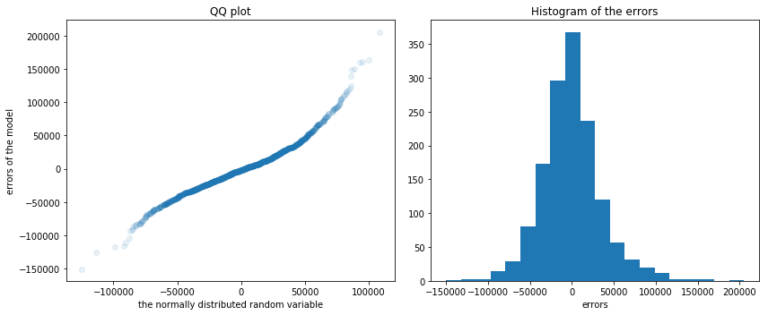

```
Jarque-Bera test statistics is 477.78620070185616 and p value is 0.0
Normality test statistics is 174.32922957218733 and p value is 1.3960108097443464e-38
```

```python
#running error normality test↔
```

### Coefficient Interpretation

**Which features are statistically significant, and which are not?** (see list below)

**Now, exclude the insignificant features from your model. Did anything change?** Rsquared improved to .84 from .75 Several more features have become insignificant.

**Interpret the statistically significant coefficients by quantifying their relations with the house prices. Which features have a more prominent effect on house prices?** See below for a listing of statistically significant independent variables by coefficient size.

**Do the results sound reasonable to you? If not, try to explain the potential reasons.** It's intuitively appealing that price is most impacted by posh neighborhoods, school zones, type of sale (e.g. foreclosure I assume),and curb appeal (external quality). Nothing suprising here.

```python
#dropping programmatically the features that are insignificant from the features set:

insign_features = list(results.pvalues[results.pvalues > 0.1].index.values)
features3 = features.drop(insign_features, axis=1)
```

```python
print(insign_features)
features3.head()
```

[output not shown]

|  | neighborhood_BrDale | neighborhood_ClearCr | neighborhood_CollgCr | neighborhood_Crawfor | neighborhood_Gilbert | neighborhood_NAmes | neighborhood_NWAmes | neighborhood_NoRidge | neighborhood_NridgHt | neighborhood_OldTown | ... | heatingqc_Gd | heatingqc_TA | salecondition_Alloca | salecondition_Normal | salecondition_Partial | overallqual | grlivarea | garagecars | garagearea | totalbsmtsf |
| --- | --- | --- | --- | --- | --- | --- | --- | --- | --- | --- | --- | --- | --- | --- | --- | --- | --- | --- | --- | --- | --- |
| 0 | 0 | 0 | 1 | 0 | 0 | 0 | 0 | 0 | 0 | 0 | ... | 0 | 0 | 0 | 1 | 0 | 7 | 1710 | 2 | 548 | 856 |
| 1 | 0 | 0 | 0 | 0 | 0 | 0 | 0 | 0 | 0 | 0 | ... | 0 | 0 | 0 | 1 | 0 | 6 | 1262 | 2 | 460 | 1262 |
| 2 | 0 | 0 | 1 | 0 | 0 | 0 | 0 | 0 | 0 | 0 | ... | 0 | 0 | 0 | 1 | 0 | 7 | 1786 | 2 | 608 | 920 |
| 3 | 0 | 0 | 0 | 1 | 0 | 0 | 0 | 0 | 0 | 0 | ... | 1 | 0 | 0 | 0 | 0 | 7 | 1717 | 3 | 642 | 756 |
| 4 | 0 | 0 | 0 | 0 | 0 | 0 | 0 | 1 | 0 | 0 | ... | 0 | 0 | 0 | 1 | 0 | 8 | 2198 | 3 | 836 | 1145 |

5 rows × 34 columns

```python
# Y is the target variable
Y = houses_df.loc[purged_index, 'saleprice']
# X is the feature set which includes
# is_male and is_smoker variables
X = features3.loc[purged_index, :]

# We need to manually add a constant
# in statsmodels' sm
X = sm.add_constant(X)

results = sm.OLS(Y, X).fit()

results.summary()
```

OLS Regression Results

| Dep. Variable: | saleprice | R-squared: | 0.836 |
| --- | --- | --- | --- |
| Model: | OLS | Adj. R-squared: | 0.832 |
| Method: | Least Squares | F-statistic: | 212.0 |
| Date: | Wed, 29 May 2019 | Prob (F-statistic): | 0.00 |
| Time: | 05:27:41 | Log-Likelihood: | -16996. |
| No. Observations: | 1452 | AIC: | 3.406e+04 |
| Df Residuals: | 1417 | BIC: | 3.425e+04 |
| Df Model: | 34 |  |  |
| Covariance Type: | nonrobust |  |  |

|  | coef | std err | t | P>\|t\| | [0.025 | 0.975] |
| --- | --- | --- | --- | --- | --- | --- |
| const | -2.965e+04 | 1.13e+04 | -2.613 | 0.009 | -5.19e+04 | -7390.207 |
| neighborhood_BrDale | -7489.4887 | 8020.038 | -0.934 | 0.351 | -2.32e+04 | 8242.935 |
| neighborhood_ClearCr | 3.574e+04 | 5948.466 | 6.009 | 0.000 | 2.41e+04 | 4.74e+04 |
| neighborhood_CollgCr | 1.283e+04 | 3407.418 | 3.767 | 0.000 | 6150.732 | 1.95e+04 |
| neighborhood_Crawfor | 3.404e+04 | 4610.951 | 7.383 | 0.000 | 2.5e+04 | 4.31e+04 |
| neighborhood_Gilbert | 1.013e+04 | 4155.327 | 2.437 | 0.015 | 1974.916 | 1.83e+04 |
| neighborhood_NAmes | 4624.9290 | 2656.807 | 1.741 | 0.082 | -586.769 | 9836.627 |
| neighborhood_NWAmes | 9339.5120 | 4087.313 | 2.285 | 0.022 | 1321.678 | 1.74e+04 |
| neighborhood_NoRidge | 5.83e+04 | 5816.018 | 10.023 | 0.000 | 4.69e+04 | 6.97e+04 |
| neighborhood_NridgHt | 4.69e+04 | 4879.368 | 9.612 | 0.000 | 3.73e+04 | 5.65e+04 |
| neighborhood_OldTown | -7536.8326 | 3718.935 | -2.027 | 0.043 | -1.48e+04 | -241.623 |
| neighborhood_SawyerW | 1.118e+04 | 4510.334 | 2.479 | 0.013 | 2333.233 | 2e+04 |
| neighborhood_Somerst | 2.122e+04 | 7332.642 | 2.894 | 0.004 | 6834.890 | 3.56e+04 |
| neighborhood_StoneBr | 5.316e+04 | 6985.105 | 7.611 | 0.000 | 3.95e+04 | 6.69e+04 |
| neighborhood_Timber | 3.021e+04 | 5438.130 | 5.556 | 0.000 | 1.95e+04 | 4.09e+04 |
| neighborhood_Veenker | 4.863e+04 | 9291.409 | 5.234 | 0.000 | 3.04e+04 | 6.69e+04 |
| mszoning_FV | 2.867e+04 | 1.24e+04 | 2.311 | 0.021 | 4332.513 | 5.3e+04 |
| mszoning_RH | 1.982e+04 | 1.23e+04 | 1.617 | 0.106 | -4228.699 | 4.39e+04 |
| mszoning_RL | 3.665e+04 | 9862.957 | 3.716 | 0.000 | 1.73e+04 | 5.6e+04 |
| mszoning_RM | 2.66e+04 | 1.01e+04 | 2.646 | 0.008 | 6877.142 | 4.63e+04 |
| exterqual_Gd | -1.904e+04 | 4783.656 | -3.981 | 0.000 | -2.84e+04 | -9658.844 |
| exterqual_TA | -1.89e+04 | 5022.872 | -3.762 | 0.000 | -2.88e+04 | -9044.758 |
| kitchenqual_Gd | -1.381e+04 | 3376.823 | -4.089 | 0.000 | -2.04e+04 | -7182.294 |
| kitchenqual_TA | -1.852e+04 | 3480.410 | -5.321 | 0.000 | -2.53e+04 | -1.17e+04 |
| heatingqc_Fa | -1.426e+04 | 4660.525 | -3.059 | 0.002 | -2.34e+04 | -5114.414 |
| heatingqc_Gd | -6073.7233 | 2436.988 | -2.492 | 0.013 | -1.09e+04 | -1293.231 |
| heatingqc_TA | -7645.4598 | 2269.770 | -3.368 | 0.001 | -1.21e+04 | -3192.990 |
| salecondition_Alloca | 1.403e+04 | 9267.845 | 1.514 | 0.130 | -4145.924 | 3.22e+04 |
| salecondition_Normal | 1.146e+04 | 2883.976 | 3.974 | 0.000 | 5802.174 | 1.71e+04 |
| salecondition_Partial | 2.499e+04 | 4263.358 | 5.862 | 0.000 | 1.66e+04 | 3.34e+04 |
| overallqual | 1.451e+04 | 1018.462 | 14.251 | 0.000 | 1.25e+04 | 1.65e+04 |
| grlivarea | 36.3999 | 2.111 | 17.244 | 0.000 | 32.259 | 40.541 |
| garagecars | 1.087e+04 | 2429.734 | 4.475 | 0.000 | 6106.020 | 1.56e+04 |
| garagearea | 14.4552 | 8.428 | 1.715 | 0.087 | -2.078 | 30.988 |
| totalbsmtsf | 17.1766 | 2.400 | 7.156 | 0.000 | 12.468 | 21.885 |

| Omnibus: | 658.943 | Durbin-Watson: | 2.014 |
| --- | --- | --- | --- |
| Prob(Omnibus): | 0.000 | Jarque-Bera (JB): | 33126.493 |
| Skew: | -1.344 | Prob(JB): | 0.00 |
| Kurtosis: | 26.245 | Cond. No. | 5.61e+04 |

Warnings:  
[1] Standard Errors assume that the covariance matrix of the errors is correctly specified.  
[2] The condition number is large, 5.61e+04. This might indicate that there are  
strong multicollinearity or other numerical problems.

```python
#listing of independent variables by coefficient size
results.params[results.pvalues < 0.1].sort_values()
```

```
const                   -29645.283590
exterqual_Gd            -19042.652956
exterqual_TA            -18897.821462
kitchenqual_TA          -18519.107114
heatingqc_Fa            -14256.683638
kitchenqual_Gd          -13806.403983
heatingqc_TA             -7645.459830
neighborhood_OldTown     -7536.832567
heatingqc_Gd             -6073.723273
garagearea                  14.455228
totalbsmtsf                 17.176554
grlivarea                   36.399894
neighborhood_NAmes        4624.928965
neighborhood_NWAmes       9339.512028
neighborhood_Gilbert     10126.170700
garagecars               10872.281204
neighborhood_SawyerW     11180.882490
salecondition_Normal     11459.495265
neighborhood_CollgCr     12834.856597
overallqual              14513.743092
neighborhood_Somerst     21218.889835
salecondition_Partial    24990.269741
mszoning_RM              26603.058118
mszoning_FV              28666.453199
neighborhood_Timber      30212.433550
neighborhood_Crawfor     34040.829563
neighborhood_ClearCr     35743.052897
mszoning_RL              36654.838588
neighborhood_NridgHt     46899.750531
neighborhood_Veenker     48634.945473
neighborhood_StoneBr     53162.240653
neighborhood_NoRidge     58295.967500
dtype: float64
```